# Tölvuverkefni 3

Enar Kornelius Leferink (ekl4@hi.is) og Sverrir Arnórsson (sva19@hi.is)

18/03/2019

```r
knitr::opts_chunk$set(echo = TRUE)
library(dplyr)
library(devtools)
library(tidyverse)
library("ggpubr")
```

```r
library(rnaturalearthhires)
library(ggplot2)
library(maps)
library(mapdata)
```

### a)

Gagnaskrá lesin inn með `read.csv()`, geymd í gagnaramma með upphafsstöfum okkar og gögnin svo hreinsuð þannig ekki vanti gildi í gagnaskrána.

```r
es<-read.csv("data98.csv")
es <- na.omit(es)
```

Breytan `hafsveadi` skilgreind með flokkunum SV, NV, NA, SA eftir fyrirframgefinni skiptingu.

```r
r2d <-function(r)
{
    lat <- floor(r/100)
    lon <- (r - lat * 100) %% 50
    halfb <- (r - 100 * lat - lon)/100
    lon <-  - (lon + 0.5)
    lat <- lat + 60 + halfb + 0.25
    data.frame(lat = lat, lon = lon)
}
reitir<-unique(es$reit)

es$hafsvaedi <- ifelse(r2d(es$reit)$lat<65 & r2d(es$reit)$lon < (-19), "SV", ifelse(r2d(es$reit)$lat>65 & r2d(es$reit)$lon <(-19), "NV", ifelse(r2d(es$reit)$lat>65 & r2d(es$reit)$lon >(-19), "NA","SA")))

es$hafsvaedi <- factor(es$hafsvaedi,levels=c("SV", "NV","NA","SA"))
```

Ný kynþroskabreyta búin til.

```r
es$kt2 <- ifelse(es$kt==1,"Ekki kynþroska","Kynþroska")
es$kt2 <- factor(es$kt2, levels=c("Ekki kynþroska","Kynþroska"))
```

### b)

Tafla sem sýnir hversi margir fiskar af hvoru kynþroskastigi veiddust á hverju hafsvæði búin til.

```r
tafla1 <- es %>% group_by( Hafssvæði = hafsvaedi, Kynþroski = kt2) %>% summarize(Fjöldi=n())
knitr::kable(tafla1)
```

| Hafssvæði | Kynþroski | Fjöldi |
| --- | --- | --- |
| SV | Ekki kynþroska | 221 |
| SV | Kynþroska | 508 |
| NV | Ekki kynþroska | 934 |
| NV | Kynþroska | 394 |
| NA | Ekki kynþroska | 981 |
| NA | Kynþroska | 215 |
| SA | Ekki kynþroska | 204 |
| SA | Kynþroska | 224 |

Önnur tafla búin til sem sýnir kynþroskahlutfallið á hverju hafsvæði fyrir sig.

```r
knitr::kable(round(prop.table(table(es$kt2,es$hafsvaedi),2),2),row.names=TRUE)
```

|  | SV | NV | NA | SA |
| --- | --- | --- | --- | --- |
| Ekki kynþroska | 0.3 | 0.7 | 0.82 | 0.48 |
| Kynþroska | 0.7 | 0.3 | 0.18 | 0.52 |

Mynd sem er lýsandi fyrir fjölda fiska af hvoru kynþroskastigi í hverjum flokki af hafsvæðunum fjórum teiknuð.

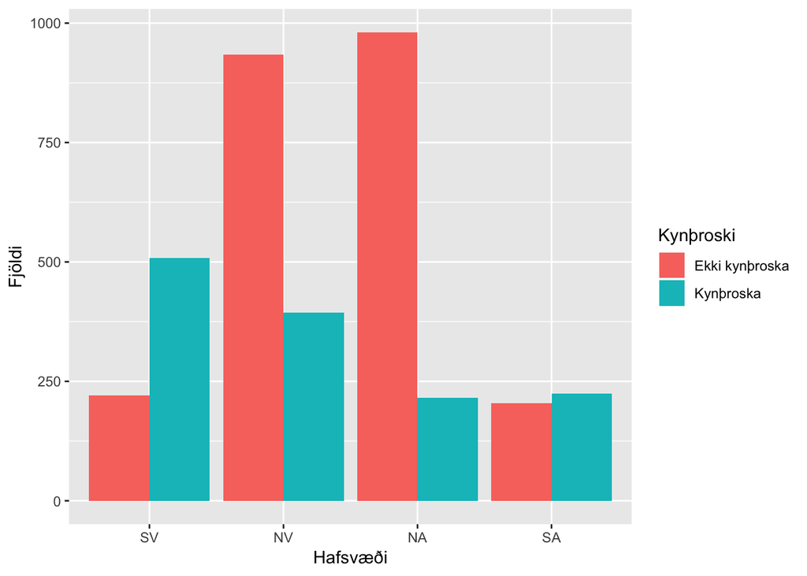

```r
ggplot(data=es, aes(fill=kt2, hafsvaedi)) + geom_bar(position="dodge")+ xlab("Hafsvæði") + ylab("Fjöldi") + labs(fill="Kynþroski")
```

### c)

Tafla sem sýnir fjölda fiska, meðallengd, meðalþyngd og staðalfrávik lengdar eftir aldri.

```r
tafla2 <- es %>% group_by('Aldur' = aldur) %>% summarize(Fjöldi = n(), 'Meðaltal lengdar'= mean(le), 'Meðaltal óslægðrar þyngdar' = mean(osl), 'Staðalfrávik lengdar eftir aldri' = sd(le))
knitr::kable(round(tafla2,2))
```

| Aldur | Fjöldi | Meðaltal lengdar | Meðaltal óslægðrar þyngdar | Staðalfrávik lengdar eftir aldri |
| --- | --- | --- | --- | --- |
| 1 | 3 | 22.67 | 102.00 | 2.08 |
| 2 | 76 | 26.30 | 165.54 | 3.72 |
| 3 | 632 | 38.55 | 529.32 | 5.28 |
| 4 | 367 | 51.26 | 1339.23 | 7.90 |
| 5 | 1211 | 61.44 | 2132.97 | 6.82 |
| 6 | 750 | 71.43 | 3424.95 | 8.70 |
| 7 | 262 | 79.19 | 4767.27 | 8.88 |
| 8 | 209 | 85.26 | 6407.29 | 9.99 |
| 9 | 135 | 88.52 | 7266.07 | 9.82 |
| 10 | 27 | 93.85 | 9392.52 | 12.88 |
| 11 | 6 | 93.67 | 10665.33 | 24.31 |
| 13 | 1 | 132.00 | 28282.00 | NA |
| 14 | 1 | 145.00 | 34484.00 | NA |
| 15 | 1 | 110.00 | 12750.00 | NA |

Hér sést að lengd og þyngd virðast tengjast og aukast með aldri. Eftir því sem fiskarnir verða eldri því verra verður matið á meðaltali lengdar. Það er bara ein mæling fyrir fiska 13, 14 og 15 ára og því er ekki hægt að reikna staðalfrávik fyrir það.

Mynd teiknuð sem sýnir lengd fiska eftir aldri þegar litið er á aldur sem samfellda breytu ásamt meðallengd fiska fyrir hvern aldurshóp sem stærri rauða punkta.

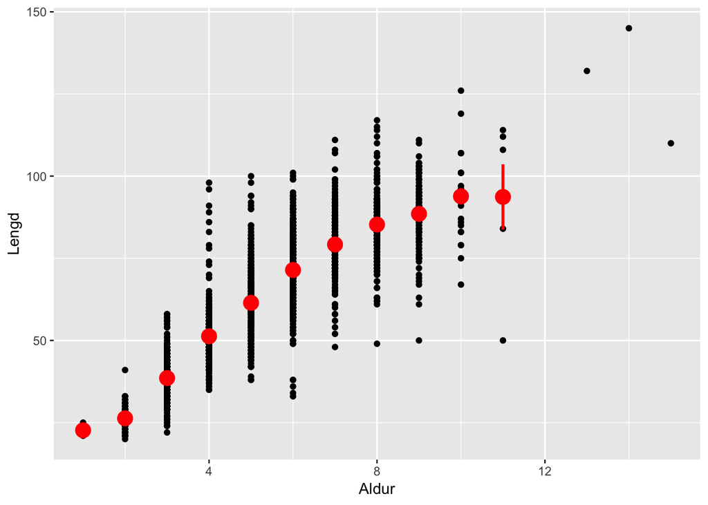

```r
ggplot(data=es, aes(aldur, le))+ geom_point()+ stat_summary(fun.data = mean_se, colour = "red", size = 1) + xlab("Aldur")+ ylab("Lengd")
```

Kassarit gert sem sýnir lengd fiska eftir aldri þegar litið er á aldur sem strjála breytu.

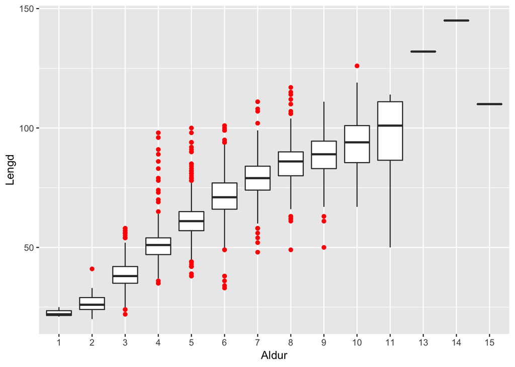

```r
ggplot(data=es,aes(factor(aldur),y=le))+geom_boxplot(outlier.color = "red") + xlab("Aldur") + ylab("Lengd")
```

Kassaritið sýnir okkur betur hvernig gögnin liggja. Við sjáum betur á hvaða bili lengdirnar eru í flestum tilvikum og sjáum einnig skýrar útlagana. Tengingin milli aldurs og lengdar kemur þess vegna skýrar fram. Á fyrri myndinni sjáum við öll gildi fyrir hvern hóp en sjáum ekki vel hversu mikill hluti af gildunum er á hverju bili.

### d)

Tvö hafsvæði valin af handahófi með `sample` fallinu eftir a hafa keyrt `set.seed()` með afmælisdegi Sverris.

```r
set.seed(0106)
hafsvaedi <- sample(levels(es$hafsvaedi),2)
print(hafsvaedi)
```

```
## [1] "SV" "NA"
```

50 fiskar valdir að handahófi af hvoru hafsvæði. Fiskarnir 100 sameinaðir í eina gagnatöflu með `rbind()`

```r
h1 <- es %>% filter(es$hafsvaedi == "SV") %>% sample_n(50)
h2 <- es %>% filter(es$hafsvaedi == "NA") %>% sample_n(50)

h <- rbind(h1,h2)
```

### e)

Kannað með tilgátuprófi með 95% marktæknikröfu hvort munur sé á meðallengd fiska á hafsvæðunum tveimur. Til þess að tilgátuprófið gefi „heilvita niðurstöðu“ þá þurfa líkurnar á því að villur séu gerðar í tilgátuprófinu að vera litlar.

$$H_0: \mu_1-\mu_2=0$$
og
$$H_1: \mu_1-\mu_2\neq0$$
Þar sem $\mu_1$ er meðallengd á fyrra hafsvæðinu og $\mu_2$ meðallengd á seinna hafsvæðinu.

Notum tilfelli 4 iii) í Fyrirlestrarnótum í tölfræði eftir Birgi Hrafnkelsson. Höfum $\alpha=0.05$.

```r
t.out<-t.test(h1$le,h2$le)
t0<-t.out$statistic
print(t.out)
```

```
##
##  Welch Two Sample t-test
##
## data:  h1$le and h2$le
## t = 5.7598, df = 94.522, p-value = 1.045e-07
## alternative hypothesis: true difference in means is not equal to 0
## 95 percent confidence interval:
##  11.1271 22.8329
## sample estimates:
## mean of x mean of y
##     74.40     57.42
```

### f)

Stuðlarit reiknað af lengd fyrir hvert hafsvæði fyrir sig. Þéttleikafall þeirrar normaldreifingar sem eðlilegt væri að búast við að gögnin fyrir hvert hafsvæði fylgdu.

```r
library(reshape2)
es.long = melt(es, id.vars='hafsvaedi', measure.vars='le', value.name='le')
```

Gögn hermd með náttúrulegu normaldreifingunni

```r
# Skilgreinum fall sem ad tekur inn gagnavigur x og
#   skilar gognum sem fylgja "natturulegu" normaldreifingu vigursins x
get_normal_density <- function(x, binwidth) {
  grid <- seq(min(x), max(x), length=100)
  data.frame(
    le = grid,
    normal_curve = dnorm(grid, mean(x), sd(x)) * length(x) * binwidth
  )
}

# Skilgreinum breytu fyrir binwidth
BW <- 3

# Buum til normaldreifd gogn fyrir hvert hafsvaedi med thvi ad
#   beita fallinu "get_normal_density" a lengdarmaelingar sem tilheyra
#   hverju hafsvaedi fyrir sig
normaldens <-
  es %>%
  group_by(hafsvaedi) %>%
  do(get_normal_density(x=.$le, binwidth=BW))
```

Grafið teiknað ásamt normaldreifingunni.

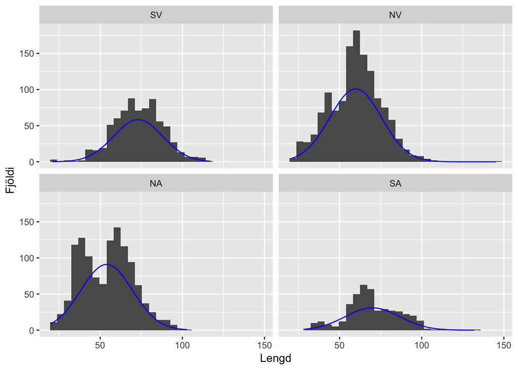

```r
ggplot(es.long, aes(le)) + geom_histogram() + geom_line(data=normaldens, aes(le,normal_curve),color="blue") + facet_wrap(vars(hafsvaedi)) + xlab("Lengd") + ylab("Fjöldi")
```

Hér má sjá að lengdin á SV-, NV-, og SA-svæðunum fylgja nokkurnveginn normaldreifingu, en það er erfiðara að segja til um SA því að það eru aðeins færri mælingar á því hafsvæði en hinum. En NA hafsvæðið er ekki alveg normaldreift því að það hefur tvo toppa sitt hvoru megin við meðaltalið. Það sést líka ef Shapiro-Wilk próf er notað.

```r
print(shapiro.test(h2$le))
```

```
##
##  Shapiro-Wilk normality test
##
## data:  h2$le
## W = 0.95399, p-value = 0.04985
```

Hér er p-gildið undir 5% svo ekki er hægt að segja með góðu móti að lengdin á NA-svæðinu sé normaldreifð

### g)

```r
n<-length(h1$le)
m<-length(h2$le)
xyind<-c(rep(1,n),rep(2,m))
Repl<-5000
z<-c(h1$le,h2$le)
p_rpt<-sum(replicate(Repl,
              abs(t0)<
                abs(
                  t.test(z[sample(1:length(z))]~xyind)$statistic
                )))/Repl
```

### h)

```r
tafla3 <- h %>% group_by( Hafssvæði = hafsvaedi, Kynþroski = kt2) %>% summarize(Fjöldi=n())
knitr::kable(tafla3)
```

| Hafssvæði | Kynþroski | Fjöldi |
| --- | --- | --- |
| SV | Ekki kynþroska | 11 |
| SV | Kynþroska | 39 |
| NA | Ekki kynþroska | 42 |
| NA | Kynþroska | 8 |

Kannað með tilgátuprófi með 95% marktæknikröfu ($\alpha=0.05$)hvort munur sé á hlutfalli kynþroska fiska á hafsvæðunum tveimur. Notum tilfelli 7) í fyrirlestrarglósunum eftir Birgi. Setjum fram núlltilgátu:
$$H_0: p_1=p_2$$
og gagntilgátuna:
$$H_1: p_1 \neq p_2$$
.

```r
n1<-nrow(h1)
x1<-nrow(filter(h1, kt2 =="Kynþroska"))
p1<-x1/n1
n2<-nrow(h2)
x2<-nrow(filter(h2, kt2 =="Kynþroska"))
p2<-x2/n2
p.hat<-(x1+x2)/(n1+n2)

binom.test(x1,n1,p1)
```

```
##
##  Exact binomial test
##
## data:  x1 and n1
## number of successes = 39, number of trials = 50, p-value = 1
## alternative hypothesis: true probability of success is not equal to 0.78
## 95 percent confidence interval:
##  0.6403881 0.8847342
## sample estimates:
## probability of success
##                   0.78
```

```r
binom.test(x2,n2,p2)
```

```
##
##  Exact binomial test
##
## data:  x2 and n2
## number of successes = 8, number of trials = 50, p-value = 1
## alternative hypothesis: true probability of success is not equal to 0.16
## 95 percent confidence interval:
##  0.07170077 0.29112631
## sample estimates:
## probability of success
##                   0.16
```

```r
h$hafsvaedi<- factor(h$hafsvaedi, levels=levels(droplevels(h$hafsvaedi)))
fisher.test(table(h$hafsvaedi, h$kt2))
```

```
##
##  Fisher's Exact Test for Count Data
##
## data:  table(h$hafsvaedi, h$kt2)
## p-value = 5.004e-10
## alternative hypothesis: true odds ratio is not equal to 1
## 95 percent confidence interval:
##  0.01712385 0.16222964
## sample estimates:
## odds ratio
## 0.05592941
```

```r
z_gildi <- (p1-p2)/sqrt(p.hat*(1-p.hat)*((1/n1)+(1/n2)))
```

### i) og j)

Fyrra hafsvæðið valið og mynd teiknuð sem sýnir sambandið milli lengdar og þyngdar fiskanna.

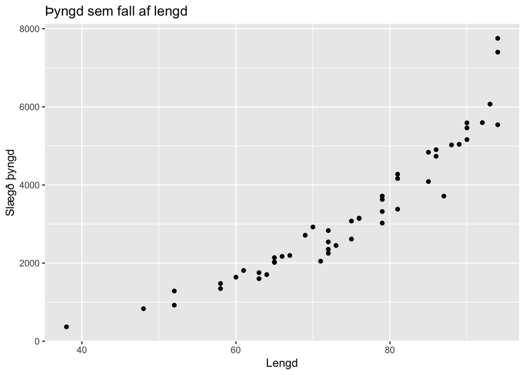

```r
ggplot(data=h1, aes(le, sl))+ geom_point()+ labs(x= "Lengd", y="Slægð þyngd", title="Þyngd sem fall af lengd")
```

Línulegt aðhvarfslíkan fyrir logrann af þyngd sem fall af logranum af lengd:

```r
fit <- lm(log(sl)~log(le), data = h1)
summary(fit)
```

```
##
## Call:
## lm(formula = log(sl) ~ log(le), data = h1)
##
## Residuals:
##      Min       1Q   Median       3Q      Max
## -0.25028 -0.07986  0.01668  0.05693  0.25131
##
## Coefficients:
##             Estimate Std. Error t value Pr(>|t|)
## (Intercept) -5.07030    0.35242  -14.39   <2e-16 ***
## log(le)      3.03196    0.08203   36.96   <2e-16 ***
## ---
## Signif. codes:  0 '***' 0.001 '**' 0.01 '*' 0.05 '.' 0.1 ' ' 1
##
## Residual standard error: 0.1111 on 48 degrees of freedom
## Multiple R-squared:  0.9661, Adjusted R-squared:  0.9654
## F-statistic:  1366 on 1 and 48 DF,  p-value: < 2.2e-16
```

Líkanið fyrir sambandið milli logranna af þyngdinni er því
$$log(\text{þyngd})=3.03\cdot log(\text{lengd})-5.07.$$

Ástæðan fyrir því að það er betra að nota lograna til að búa til aðhvarfslíkan er að sambandið er ekki línulegt milli þyngdarinnar og lengdar, en þegar logrinn er tekinn verður sambandið línulegt. Það er ekki algilt að samband milli hluta sé línulegt og er það raunar algengara að það sé veldislegt. Það er auðveldara að vinna með línuleg líkön þannig er gott er að taka logrann.

Graf af logranum af þyngd sem falli af logranum af lengd. Hér teiknum við einnig jöfnu bestu línu frá líkaninu (fyrri hluti j).

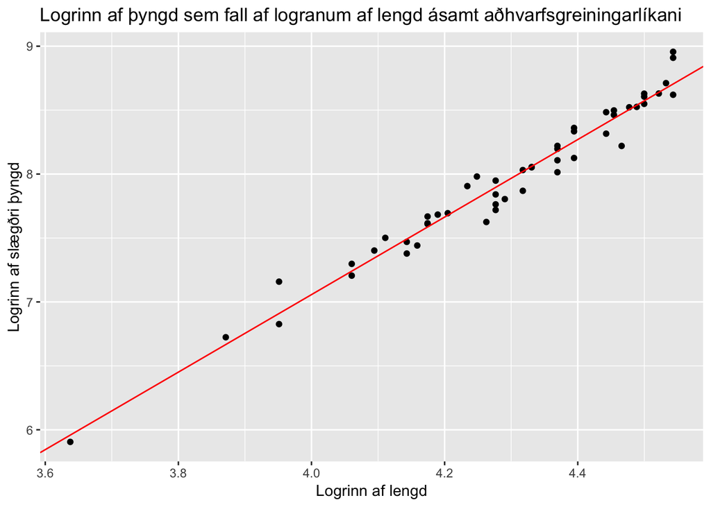

```r
ggplot(data=h1, aes(log(le), log(sl)))+ geom_point() + geom_abline(slope = fit$coefficients[2], intercept = fit$coefficients[1],color="red") + labs(x= "Logrinn af lengd", y="Logrinn af slægðri þyngd", title="Logrinn af þyngd sem fall af logranum af lengd ásamt aðhvarfsgreiningarlíkani")
```

Gildið á $R^2$ fyrir líkanið okkar er, eins og kom fram ofar í þessum lið, $R^2\simeq0.96$. Það telst nokkuð gott og lýsir líkanið 96% af breytileika gagnanna.

Teiknum nú bestu línuna sem við bjuggum til fyrir lograskala á raunskala.

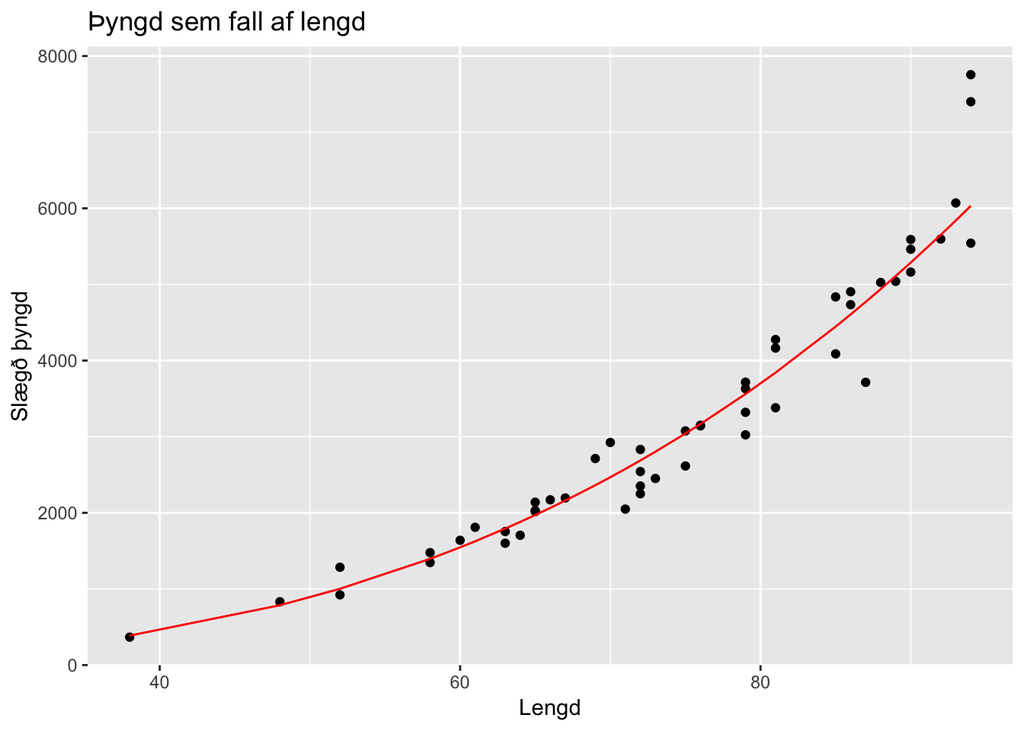

```r
gogn_likan <-
  data.frame(
    x = exp(fit$model[['log(le)']]),
    y = exp(predict(fit))
    )

ggplot(data=h1, aes(le, sl))+ geom_point()+ labs(x= "Lengd", y="Slægð þyngd", title="Þyngd sem fall af lengd") + geom_line(data=gogn_likan, aes(x,y),color="red")
```

### k)

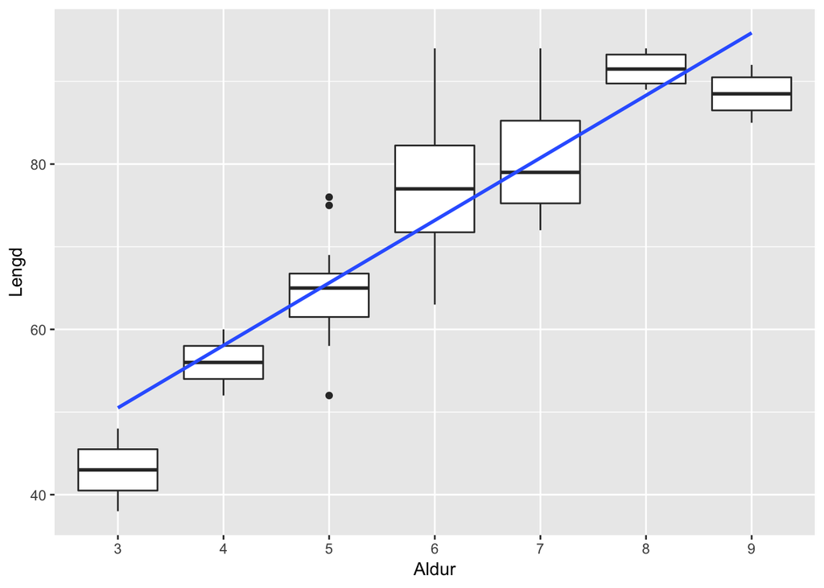

```r
ggplot(data=h1,aes(factor(aldur),y=le))+geom_boxplot() + xlab("Aldur") + ylab("Lengd") + geom_smooth(method='lm', se=FALSE, aes(group=1))
```

```r
litid <- lm(le~aldur, data=h1)
stort <- lm(le~factor(aldur), data=h1)
likon.mat <-anova(litid, stort)
print(likon.mat)
```

```
## Analysis of Variance Table
##
## Model 1: le ~ aldur
## Model 2: le ~ factor(aldur)
##   Res.Df    RSS Df Sum of Sq      F  Pr(>F)
## 1     48 2729.6
## 2     43 2073.8  5    655.84 2.7198 0.03198 *
## ---
## Signif. codes:  0 '***' 0.001 '**' 0.01 '*' 0.05 '.' 0.1 ' ' 1
```

### Bónusspurning:

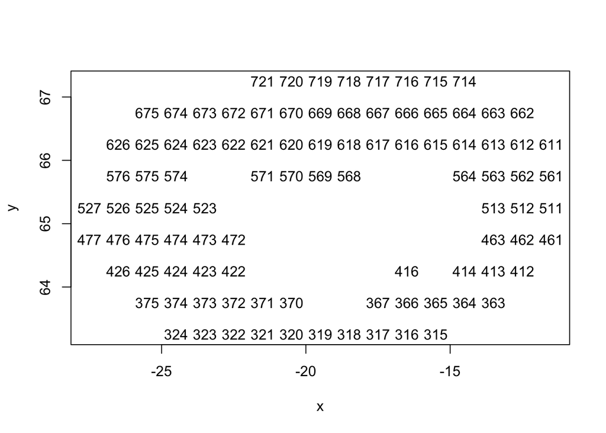

```r
x<-r2d(reitir)$lon
y<-r2d(reitir)$lat

plot(x,y,type='n')
text(x,y,as.character(reitir))
```

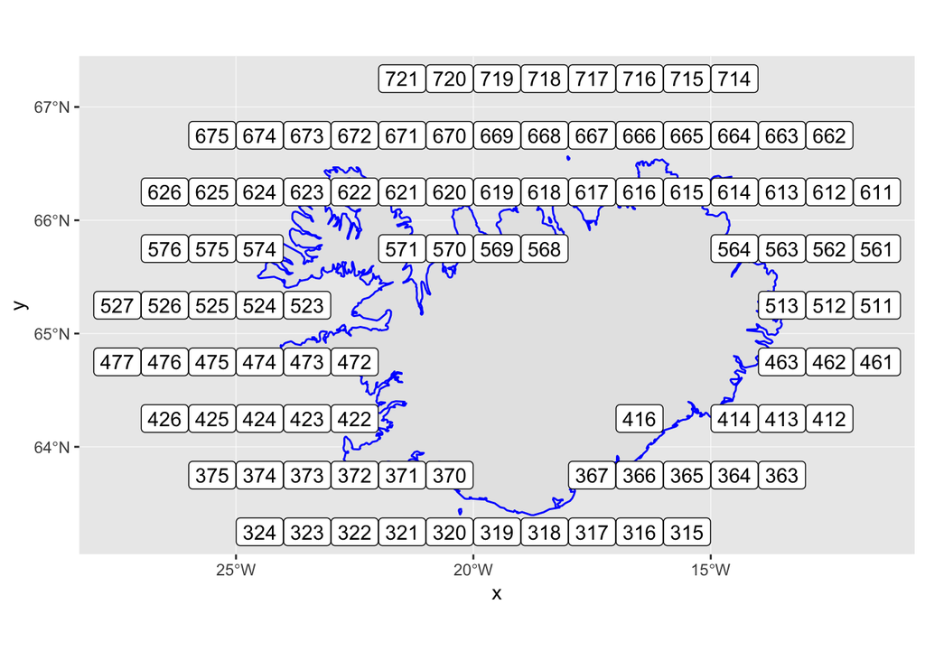

```r
world <- sf::st_as_sf(rnaturalearthhires::countries10)
island <- world %>% filter(NAME=="Iceland")
tr<-data.frame(x=x, y=y, label=as.character(reitir))
graf <- ggplot(data=island,aes()) + geom_sf(color="blue")
graf <- graf + geom_point(data = tr, aes(x,y),color="red")+geom_label(data = tr, aes(x,y,label=label))
graf + scale_y_continuous(breaks = seq(63,68,1))
```